# Bilinguale Vorhersagemodellierung: Swiftkey Meilensteinbericht (EN & DE)

Altamash Ali

26. Januar 2026

[figure not shown]

View in English

# Management Zusammenfassung

### Projektziel

Untersuchung des HC Corpora-Datensatzes (Blogs, News und Twitter), um eine Grundlage für einen leistungsstarken Algorithmus zur Wortvorhersage zu schaffen.

# Datenstatistiken

Vor der Bereinigung habe ich die deutschen Rohdateien analysiert, um deren Umfang und Skalierbarkeit für die finale Wortvorhersage zu bewerten.

```r
de_files <- c("de_DE.blogs.txt", "de_DE.news.txt", "de_DE.twitter.txt")
blogs_de <- readLines("de_DE.blogs.txt", encoding = "UTF-8", skipNul = TRUE, warn=F)
news_de <- readLines("de_DE.news.txt", encoding = "UTF-8", skipNul = TRUE, warn=F)
twitter_de <- readLines("de_DE.twitter.txt", encoding = "UTF-8", skipNul = TRUE, warn=F)

summary_table_de <- data.frame(
    Datei = c("Blogs", "News", "Twitter"),
    Groesse_MB = sapply(de_files, function(f) file.info(f)$size / 1024^2),
    Zeilenanzahl = c(length(blogs_de), length(news_de), length(twitter_de)),
    Wortanzahl = c(sum(stri_count_words(blogs_de)), sum(stri_count_words(news_de)), sum(stri_count_words(twitter_de)))
)

kable(summary_table_de, caption = "Zusammenfassung der deutschen Rohdateien", digits = 2)
```

Zusammenfassung der deutschen Rohdateien

|  | Datei | Groesse_MB | Zeilenanzahl | Wortanzahl |
| --- | --- | --- | --- | --- |
| de_DE.blogs.txt | Blogs | 81.50 | 181958 | 6206038 |
| de_DE.news.txt | News | 91.16 | 244743 | 13375155 |
| de_DE.twitter.txt | Twitter | 72.08 | 947774 | 11648290 |

# Datenbereinigung & Stichprobenziehung

Um eine schnelle App-Reaktion zu gewährleisten, wurde eine 1% Zufallsstichprobe gezogen. Die Bereinigung umfasste: Umwandlung in Kleinschreibung, Entfernung von Satzzeichen und Filtern von Sonderzeichen.

```r
set.seed(1234)
sample_de <- c(sample(blogs_de, length(blogs_de) * 0.01),
               sample(news_de, length(news_de) * 0.01),
               sample(twitter_de, length(twitter_de) * 0.01))

sample_df_de <- data.frame(text = sample_de, stringsAsFactors = FALSE)
```

# Explorative Analyse

Ich habe N-Gramme (Wortfolgen) analysiert, um die Wahrscheinlichkeit von Wortübergängen zu bestimmen—die Kernlogik meines Prädiktors.

### Häufigste Bigramme (Wortpaare)

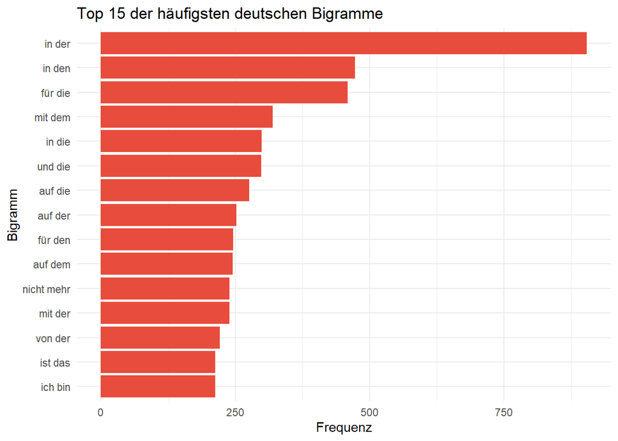

```r
bigrams_de <- sample_df_de %>%
    unnest_tokens(bigram, text, token = "ngrams", n = 2) %>%
    count(bigram, sort = TRUE) %>%
    top_n(15, n)

ggplot(bigrams_de, aes(x = reorder(bigram, n), y = n)) +
    geom_col(fill = "#e74c3c") +
    coord_flip() +
    labs(title = "Top 15 der häufigsten deutschen Bigramme", x = "Bigramm", y = "Frequenz") +
    theme_minimal()
```

# Modellierungsstrategie

### 1. Der Algorithmus

Ich implementiere ein Katz-Back-off-Modell.

- `Trigramm-Match :` Suche nach Übereinstimmung basierend auf den letzten zwei Wörtern.
- `Bigramm-Match :` Rückgriff auf Ein-Wort-Match, falls kein Trigramm existiert.
- `Unigramm-Match :` Liefert das häufigste Wort im Datensatz als Fallback.

### 2. Performance-Optimierung

- `Pruning :` Entfernung von N-Grammen mit nur einem Vorkommen.
- `Datenstruktur :` Nutzung von .rds-Dateien für optimierte Ladezeiten.

### Quellcode

Der vollständige Quellcode für dieses Projekt und die fertige Shiny-Anwendung sind auf GitHub verfügbar: [Quellcode auf GitHub ansehen](https://github.com/realAltamashAli/bilingual-swiftkey-nlp)